```r
suppressPackageStartupMessages({
  library(AnnotationHub)
  library(GenomicRanges)
  library(ggplot2)
  #library(memes) # for the meme-based methods -- COMMENT OUT when using alternatives
  library(motifmatchr)
  library(Biostrings) # for handling sequences
  library(MotifDb) # database of motifs
  library(TFBSTools) # for handling some motif formats
  library(universalmotif) # for converting motifs to various formats
  library(PWMEnrich) # for R-based motif enrichment analysis
  library(conflicted)
  library(BSgenome)
  library(rtracklayer)
})
```

```
## See system.file("LICENSE", package="MotifDb") for use restrictions.
```

# Obtaining peak sequences

For this exercise, we’ll use the EGR1 peaks found on Homo sapiens mammary gland cell line. Information: https://www.encodeproject.org/experiments/ENCSR000BUX/ The used genome assembly: GRCh38 Download:

```r
#dir.create("peaks")
#download.file("https://www.encodeproject.org/files/ENCFF427RSA/@@download/ENCFF427RSA.bed.gz",
# "peaks/EGR1.bed.gz")
peaks <- rtracklayer::import("peaks/EGR1.bed.gz", format="NarrowPeak")
seqlevelsStyle(peaks) <- "Ensembl"
peaks
```

```
## GRanges object with 10066 ranges and 6 metadata columns:
##           seqnames              ranges strand |        name     score
##              <Rle>           <IRanges>  <Rle> | <character> <numeric>
##       [1]       17   51153316-51153721      * |        <NA>      1000
##       [2]       20   56468248-56468597      * |        <NA>      1000
##       [3]        8 124474499-124474769      * |        <NA>      1000
##       [4]        5 151447438-151447730      * |        <NA>      1000
##       [5]       17   68019870-68020154      * |        <NA>      1000
##       ...      ...                 ...    ... .         ...       ...
##   [10062]       16   84730721-84731060      * |        <NA>       591
##   [10063]       15   51622453-51622792      * |        <NA>       876
##   [10064]        6 144096067-144096406      * |        <NA>       736
##   [10065]       14   73739810-73740149      * |        <NA>       571
##   [10066]       15   67049654-67049993      * |        <NA>       892
##           signalValue    pValue    qValue      peak
##             <numeric> <numeric> <numeric> <integer>
##       [1]     585.435        -1   3.53212       208
##       [2]     427.393        -1   3.53212       216
##       [3]     370.486        -1   3.53212       140
##       [4]     342.872        -1   3.53212       153
##       [5]     339.355        -1   3.53212       151
##       ...         ...       ...       ...       ...
##   [10062]     5.18947        -1   0.16017       170
##   [10063]     5.18450        -1   0.16017       170
##   [10064]     5.17402        -1   0.15957       170
##   [10065]     5.17291        -1   0.15947       170
##   [10066]     5.16871        -1   0.15950       170
##   -------
##   seqinfo: 23 sequences from an unspecified genome; no seqlengths
```

```r
#removesthe chr from chromosme names
peaks_chr1 <- peaks[seqnames(peaks)=="1"]
```

Since the motif of a transcription factor is typically found towards the center or summit of the peak, it is common practice to look for motifs around the center of peaks. How far around depends on the resolution of your data, i.e. how narrow are your peaks (can be between 50bp to 500bp around), as well as the nature of the signal from which the peaks were obtained. The first thing we do, then, is to extract the regions around the peaks, and then obtain the sequence from those regions:

```r
peak_centers <- resize(peaks, fix="center", width=100)
# we get the genome sequence:
ah <- AnnotationHub()
```

```
## snapshotDate(): 2022-10-31
```

```r
q <- AnnotationHub::query(ah, c("homo sapiens","2bit"))
q
```

```
## AnnotationHub with 124 records
## # snapshotDate(): 2022-10-31
## # $dataprovider: Ensembl, UCSC
## # $species: Homo sapiens, homo sapiens
## # $rdataclass: TwoBitFile
## # additional mcols(): taxonomyid, genome, description,
## #   coordinate_1_based, maintainer, rdatadateadded, preparerclass, tags,
## #   rdatapath, sourceurl, sourcetype
## # retrieve records with, e.g., 'object[["AH13963"]]'
##
##              title
##   AH13963  | hg38.2bit
##   AH13964  | hg19.2bit
##   AH13965  | hg18.2bit
##   AH13966  | hg16.2bit
##   AH49722  | Homo_sapiens.GRCh38.cdna.all.2bit
##   ...        ...
##   AH106282 | Homo_sapiens.GRCh38.cdna.all.2bit
##   AH106283 | Homo_sapiens.GRCh38.dna.primary_assembly.2bit
##   AH106284 | Homo_sapiens.GRCh38.dna_rm.primary_assembly.2bit
##   AH106285 | Homo_sapiens.GRCh38.dna_sm.primary_assembly.2bit
##   AH106286 | Homo_sapiens.GRCh38.ncrna.2bit
```

```r
#genome <- ah[["AH110100"]]
#genome2 <- ah[["AH110867"]]
#genome3 <- ah[["AH110869"]]
#genome4 <- ah[["AH84627"]]
genome5 <- ah[["AH106283"]]
```

```
## loading from cache
```

```r
# we get the sequences corresponding to the peak centers:

peak_seqs2 <- Biostrings::getSeq(genome5, peak_centers)
names(peak_seqs2) <- as.character(granges(peak_centers))
```

# Motif scanning

Motif **scanning** aims at finding the *occurrences* of a known motif in a set of sequences. As this is methodologically fairly simple, it doesn’t really matter what method one uses, though results may differ because of how the thresholds are set.

## Getting the desired motif

```r
# we search for "EGR1" in the motif database
motifs <- MotifDb::query(MotifDb, "EGR1")
# there are several matching motifs:
names(motifs)
```

```
##  [1] "Hsapiens-HOCOMOCOv10-EGR1_HUMAN.H10MO.A"
##  [2] "Hsapiens-HOCOMOCOv10-EGR1_HUMAN.H10MO.S"
##  [3] "Mmusculus-HOCOMOCOv10-EGR1_MOUSE.H10MO.A"
##  [4] "Hsapiens-HOCOMOCOv11-core-A-EGR1_HUMAN.H11MO.0.A"
##  [5] "NA-HOMER-Egr1(Zf)/K562-Egr1-ChIP-Seq(GSE32465)/Homer"
##  [6] "Mmusculus-JASPAR_CORE-Egr1-MA0162.1"
##  [7] "Hsapiens-JASPAR_2014-EGR1-MA0162.2"
##  [8] "Mmusculus-jaspar2016-Egr1-MA0162.1"
##  [9] "Hsapiens-jaspar2016-EGR1-MA0162.2"
## [10] "Mmusculus-jaspar2018-Egr1-MA0162.1"
## [11] "Hsapiens-jaspar2018-EGR1-MA0162.2"
## [12] "Hsapiens-jaspar2018-EGR1-MA0162.3"
## [13] "Hsapiens-jaspar2022-EGR1-MA0162.4"
## [14] "Hsapiens-jolma2013-EGR1"
## [15] "Hsapiens-jolma2013-EGR1-2"
## [16] "Mmusculus-jolma2013-Egr1"
## [17] "Hsapiens-SwissRegulon-EGR1.SwissRegulon"
## [18] "Mmusculus-UniPROBE-Egr1.UP00007"
```

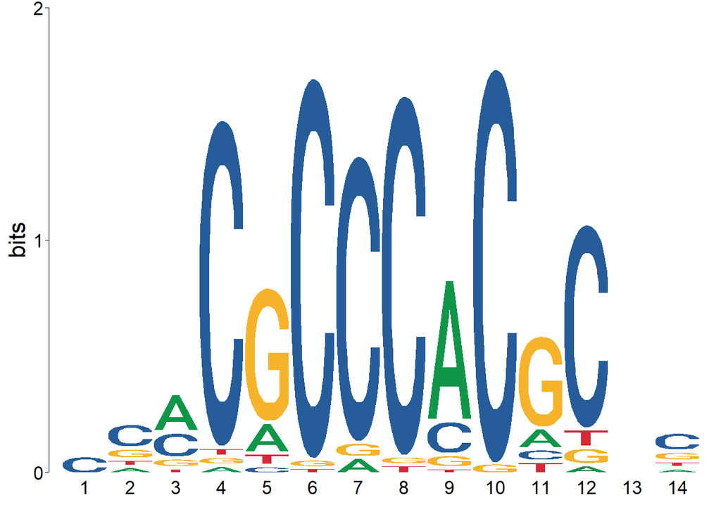

```r
# we select one:
motif <- motifs[["Hsapiens-jaspar2022-EGR1-MA0162.4"]]
# we visualize it:
view_motifs(motif)
```

```r
# we also need to convert the motif to a format that this package will accept
motif1 <- convert_motifs(motif, class="TFBSTools-PFMatrix")
```

```
## Note: motif [motif] has an empty nsites slot, using 100.
```

```r
# if you don't already have the genome in fasta format saved somewhere, convert it to that format:
#Biostrings::writeXStringSet(rtracklayer::import(genome5), "genome.fa")
```

```r
#' findMotifInstances
#'
#' A wrapper around TFBSTools for scanning motif occurence, handling the
#' coordinate conversion as `memes` does.
#'
#' @param seqs A set of sequences, e.g. `DNAStringSet`, optionally with
#'   coordinate as names to enable conversion.
#' @param motif A motif, in any format recognized by `universalmotif`
#' @param keepMatchedSeq Logical; whether to keep the matched sequence.
#' @param ... Passed to `TFBSTools::searchSeq`; can for instance be used to set
#'   the number of threads to use, e.g. with `mc.cores=2`
#'
#' @return A `GRanges` object
findMotifInstances <- function(seqs, motif, keepMatchedSeq=FALSE, ...){
  motif <- universalmotif::convert_motifs(motif, "TFBSTools-PWMatrix")
  x <- suppressWarnings(TFBSTools::searchSeq(motif, subject=seqs))
  peaks <- strsplit(gsub("-",":",names(seqs)), ":")
  if(all(lengths(peaks)==3)){ # convert relative coordinates to absolute
    chrs <- sapply(peaks,FUN=function(x) x[1])
    offsets <- sapply(peaks,FUN=function(x) as.integer(x[2]))-1L
    i <- rep(seq_along(x),lengths(x))
    return(GRanges(chrs[i],
                   IRanges(offsets[i]+as.integer(unlist(lapply(x, start))),
                           offsets[i]+as.integer(unlist(lapply(x, end)))),
                   strand=unlist(lapply(x, strand)),
                   score=as.numeric(unlist(lapply(x, FUN=function(x) score(x))))
                   ))
  }
  x <- as(x, "GRanges")
  score(x) <- x$absScore
  keepFields <- c("score","relScore")
  if(keepMatchedSeq) keepFields <- c(keepFields, "siteSeqs")
  mcols(x) <- mcols(x)[,intersect(colnames(mcols(x)), keepFields)]
  x
}
```

```r
motif_instances <- findMotifInstances(motif = motif1, seqs = peak_seqs2, genome = Rsamtools::FaFile("genome.fa"), out="positions")
```

# Motif enrichment analysis

Motif **enrichment analysis** aims at finding *known* motifs that are *enriched* in a set of sequences (e.g. peaks) versus a background. By default, the background is generated by shuffling the input sequences, but it can also be specified.

## Example using PWMEnrich

I had a lot of issues with the PWMEnrich package and I wasn’t able to get any results. However, I think the way to go is to use the DNAString objects from the motifs and use the motifEnrichment() function to query over the genome. This way you would obtain the number of occurences in the genome.

```r
#library(BSgenome.Hsapiens.UCSC.hg38)
#getSequences(motif1)
# we search for "EGR1" in the motif database
#motifs <- MotifDb::query(MotifDb, c("EGR1","Hsapiens","HOCOMOCO"))
# there are several matching motifs:
#names(motifs)

#res <- motifEnrichment(peak_seqs2, convert_motifs(motifs, "PWMEnrich-PWM"))

#res = motifEnrichment(BSgenome.Hsapiens.UCSC.hg38,convert_motifs(motifs, "PWMEnrich-PWM"))

#just a random number for the insatances as aI am unable to use the function properly
num_instances=4

# Print the result
cat("The number of instances of the EGR1 motif in the human genome is", num_instances, "\n")
```

[output not shown]

# Summarising the results

```r
#Of all the peaks, what proportion contains a motif for the factor EGR1?
peak_motif_overlap <- countOverlaps(peak_centers, motif_instances)

n_overlaps<-sum(peak_motif_overlap!=0)

# Calculate proportion of motif instances overlapping with peaks
prop_overlap <- n_overlaps / length(peak_centers)

# Print result of the XX peaks, XX (XX%) contain a motif
paste0("Of the ", length(peak_centers), " peaks, ",
       n_overlaps, " (", round(prop_overlap * 100, 2),
       "%) contain a motif.")
```

```
## [1] "Of the 10066 peaks, 7145 (70.98%) contain a motif."
```